# 베이지안 계층 군집분석을 활용한 비즈니스 데이터 분석

중앙대학교 응용통계학과 류성균, 황범석

# 1 시뮬레이션

## 1.1 6차원 혼합 모형

### 1.1.1 시뮬레이션 모형

$$p_1 * MVN(\mu_{1}, \Sigma_6) + p_2 * MVN(\mu_{2}, \Sigma_6) + p_3 * MVN(\mu_{3}, \Sigma_6)$$

이 때, $\mu_i = (\mu_{i1}, \cdots, \mu_{i6})^T$, $\Sigma_6 = f(\sigma_1^2, \cdots , \sigma_6^2, \rho)$, $\rho$는 ‘UCI Wholesale customer’ 데이터 중 연속형 변수의 상관계수 행렬을 사용함.

### 1.1.2 각 시뮬레이션 모수 정의

- $\mu$

| Setting | $\mu_1$ | $\mu_2$ | $\mu_3$ |
| --- | --- | --- | --- |
| $A_6$ | -10 | 0 | 10 |
| $B_6$ | -15 | 0 | 15 |
| $C_6$ | -10 | 0 | 10 |
| $D_6$ | -20 | 0 | 20 |
| $E_6$ | -10 | 0 | 10 |
| $F_6$ | -30 | 0 | 30 |

- $\sigma^2$

| Setting | $\sigma_1^2$ | $\sigma_2^2$ | $\sigma_3^2$ | $\sigma_4^2$ | $\sigma_5^2$ | $\sigma_6^2$ |
| --- | --- | --- | --- | --- | --- | --- |
| $A_6$ | 100 | 100 | 50 | 50 | 30 | 10 |
| $B_6$ | 50 | 50 | 50 | 30 | 30 | 10 |
| $C_6$ | 50 | 50 | 50 | 30 | 30 | 10 |
| $D_6$ | 50 | 50 | 50 | 30 | 30 | 10 |
| $E_6$ | 50 | 50 | 50 | 30 | 30 | 10 |
| $F_6$ | 100 | 100 | 50 | 50 | 30 | 10 |

- $p$

| Setting | $p_1$ | $p_2$ | $p_3$ |
| --- | --- | --- | --- |
| $E_6$ | 0.1 | 0.8 | 0.1 |
| others | 0.3 | 0.4 | 0.3 |

### 1.1.3 성능 측도 결과

- 비교 모형
  - 베이지안 계층 군집분석 : BHC
  - 기존 계층적 군집분석 - 평균 연결법 : Average
  - 기존 계층적 군집분석 - 완전 연결법 : Complete
- 사용한 성능 측도
  - ARI
  - Cluster Purity
  - 추가적으로 각 방법이 추정한 군집의 갯수도 기재.

| **ARI** | $A_6$ | $B_6$ | $C_6$ | $D_6$ | $E_6$ | $F_6$ |
| --- | --- | --- | --- | --- | --- | --- |
| BHC | **0.431** | 0.689 | **0.453** | 0.821 | 0.031 | 0.86 |
| Average | 0.2 | **0.92** | 0.319 | **0.991** | **0.266** | **0.999** |
| Complete | 0.285 | 0.706 | 0.36 | 0.965 | 0.261 | 0.996 |

| **Purity** | $A_6$ | $B_6$ | $C_6$ | $D_6$ | $E_6$ | $F_6$ |
| --- | --- | --- | --- | --- | --- | --- |
| BHC | **0.796** | 0.937 | **0.829** | 0.977 | 0.807 | 0.988 |
| Average | 0.528 | **0.972** | 0.597 | **0.997** | **0.841** | **1** |
| Complete | 0.578 | 0.841 | 0.619 | 0.987 | 0.828 | 0.999 |

| **n(cluster) : Mean** | $A_6$ | $B_6$ | $C_6$ | $D_6$ | $E_6$ | $F_6$ |
| --- | --- | --- | --- | --- | --- | --- |
| BHC | 5 | 5 | 5 | 5 | 4 | 5 |
| Average | 3 | 3 | 2 | 3 | 2 | 3 |
| Complete | 3 | 3 | 2 | 3 | 2 | 3 |

| **n(cluster) : Var** | $A_6$ | $B_6$ | $C_6$ | $D_6$ | $E_6$ | $F_6$ |
| --- | --- | --- | --- | --- | --- | --- |
| BHC | 1.092 | 0.996 | 0.899 | 0.64 | 0.86 | 0.406 |
| Average | 0.131 | 0.05 | 0.21 | 0 | 0.126 | 0 |
| Complete | 0.01 | 0.24 | 0.057 | 0.02 | 0.317 | 0 |

## 1.2 10차원 혼합 모형

### 1.2.1 시뮬레이션 모형

$$p_1^* * MVN(\mu_{1}^*, \Sigma_{10}) + p_2^* * MVN(\mu_{2}^*, \Sigma_{10}) + p_3^* * MVN(\mu_{3}^*, \Sigma_{10})$$

이 때, $\mu_i^* = (\mu_{i1}^*, \cdots, \mu_{i3}^*)^T$, $\Sigma_{10} = f(\sigma_1^2, \cdots , \sigma_{10}^2, \rho)$, $\rho$는 QR decomposition을 활용하여 양정치 행렬을 생성한 뒤 이에서 상관계수 행렬을 추출함.

### 1.2.2 각 시뮬레이션 모수 정의

- $\mu$

| Setting | $\mu_1$ | $\mu_2$ | $\mu_3$ |
| --- | --- | --- | --- |
| $A$ | -10 | 0 | 10 |
| $B$ | -15 | 0 | 15 |
| $C$ | -10 | 0 | 10 |
| $D$ | -15 | 0 | 15 |

- $\sigma^2$

| Setting | $\sigma_1^2$ | $\sigma_2^2$ | $\sigma_3^2$ | $\sigma_4^2$ | $\sigma_5^2$ | $\sigma_6^2$ | $\sigma_7^2$ | $\sigma_8^2$ | $\sigma_9^2$ | $\sigma_{10}^2$ |
| --- | --- | --- | --- | --- | --- | --- | --- | --- | --- | --- |
| $A$ | 50 | 50 | 50 | 50 | 50 | 30 | 30 | 30 | 10 | 10 |
| $B$ | 100 | 100 | 100 | 50 | 50 | 50 | 30 | 30 | 30 | 10 |
| $C$ | 100 | 100 | 100 | 50 | 50 | 50 | 30 | 30 | 30 | 10 |
| $D$ | 100 | 100 | 100 | 50 | 50 | 50 | 30 | 30 | 30 | 10 |

- $p$

| Setting | $p_1$ | $p_2$ | $p_3$ |
| --- | --- | --- | --- |
| $D$ | 0.1 | 0.8 | 0.1 |
| others | 0.3 | 0.4 | 0.3 |

### 1.2.3 성능 측도 결과

- 사용한 성능 측도

| **ARI** | $A$ | $B$ | $C$ | $D$ |
| --- | --- | --- | --- | --- |
| BHC | **0.926** | 0.982 | **0.852** | 0.873 |
| Average | 0.861 | **0.993** | 0.426 | **0.984** |
| Complete | 0.834 | 0.968 | 0.455 | 0.933 |

| **Purity** | $A$ | $B$ | $C$ | $D$ |
| --- | --- | --- | --- | --- |
| BHC | **0.981** | 0.996 | **0.956** | 0.983 |
| Average | 0.92 | **0.998** | 0.645 | **0.996** |
| Complete | 0.912 | 0.988 | 0.657 | 0.985 |

| **n(cluster) : Mean** | $A$ | $B$ | $C$ | $D$ |
| --- | --- | --- | --- | --- |
| BHC | 3 | 3 | 3 | 3 |
| Average | 3 | 3 | 2 | 3 |
| Complete | 3 | 3 | 2 | 3 |

| **n(cluster) : Var** | $A$ | $B$ | $C$ | $D$ |
| --- | --- | --- | --- | --- |
| BHC | 0.176 | 0.099 | 0.295 | 0.522 |
| Average | 0.345 | 0.057 | 0.343 | 0.059 |
| Complete | 0.176 | 0.02 | 0.039 | 0.048 |

# 2 UCI ‘Wholesale customer’ data

- 출처 : https://archive.ics.uci.edu/ml/datasets/wholesale+customers

## 2.1 데이터 개요

- 포르투칼 도매 유통업체의 고객 데이터이다.
- 각각의 변수 내용은 아래와 같다.

| 변수명 | 내용 | 기타 |
| --- | --- | --- |
| Channel | 유통 채널 | 1: 호텔, 레스토랑, 까페 / 2: 소매업체 |
| Region | 지역 | 1: 리스본 / 2: 포르투 / 3: 기타지역 |
| Fresh | 연간 신선식품 지출액 | 연속형 |
| Milk | 연간 유제품 지출액 | 연속형 |
| Grocery | 연간 식료품 지출액 | 연속형 |
| Frozen | 연간 냉동식품 지출액 | 연속형 |
| Detergents_Paper | 연간 세제 및 휴지 품목 지출액 | 연속형 |
| Delicassen | 연간 조리식품 지출액 | 연속형 |

## 2.2 특성

- BHC의 경우 모형 적합과정에서 이산화(Discretizing)을 하기 때문에 비정규성, 이상치, 변환 등에 robust하다.
- 이에 다른 전처리 없이 바로 군집분석을 수행할 수 있다.

```
##  Channel Region      Fresh             Milk          Grocery
##  1:298   1: 77   Min.   :     3   Min.   :   55   Min.   :    3
##  2:142   2: 47   1st Qu.:  3128   1st Qu.: 1533   1st Qu.: 2153
##          3:316   Median :  8504   Median : 3627   Median : 4756
##                  Mean   : 12000   Mean   : 5796   Mean   : 7951
##                  3rd Qu.: 16934   3rd Qu.: 7190   3rd Qu.:10656
##                  Max.   :112151   Max.   :73498   Max.   :92780
##      Frozen        Detergents_Paper    Delicassen
##  Min.   :   25.0   Min.   :    3.0   Min.   :    3.0
##  1st Qu.:  742.2   1st Qu.:  256.8   1st Qu.:  408.2
##  Median : 1526.0   Median :  816.5   Median :  965.5
##  Mean   : 3071.9   Mean   : 2881.5   Mean   : 1524.9
##  3rd Qu.: 3554.2   3rd Qu.: 3922.0   3rd Qu.: 1820.2
##  Max.   :60869.0   Max.   :40827.0   Max.   :47943.0
```

## 2.3 BHC 결과

- 8개 변수 모두 사용

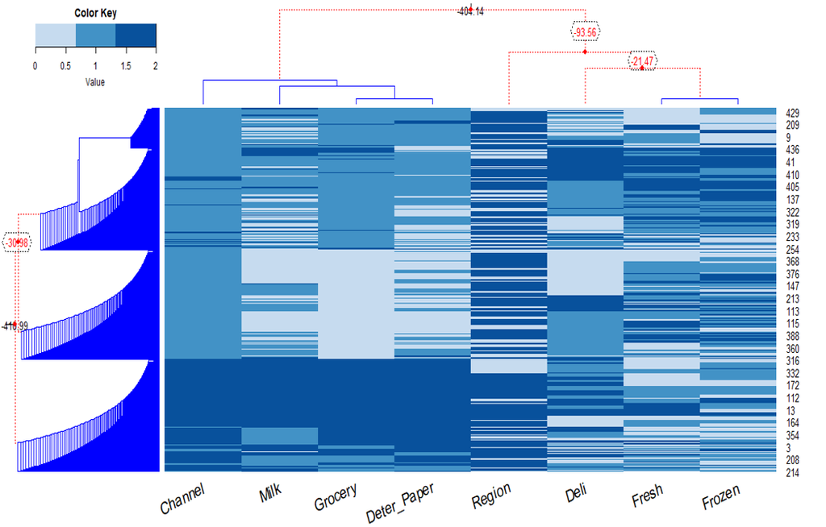

# 3 UCI ‘Semiconductor’ data

- 출처 : https://archive.ics.uci.edu/ml/datasets/secom

## 3.1 데이터 개요

- UCI Machin Learning Repository에 공개된 반도체 공정 데이터
- 1567개의 관측치와 591개의 변수로 구성
- 변수에서 공정 관리에 유의미한 변수와 무의미한 변수/노이즈가 섞여있음
- ‘Wholesale customer’ data와 다르게 변수의 범위가 크게 차이가 나고, 결측치와 분산이 0인 ’상수 변수’가 존재해 전처리가 필요하다.
- 각각의 변수 내용은 아래와 같다.

| 변수명 | 내용 | 기타 |
| --- | --- | --- |
| Time | 공정시간 | train/test dataset 기준 |
| X0~X589 | 공정 신호 데이터 | 변수 판별 필요 |
| Pass.Fail | 양호: -1 /불량: 1 | 결과 변수 |

```r
dim(semicon)
```

```
## [1] 1567  592
```

```
##        X0             X9                 X24            Pass.Fail
##  Min.   :2743   Min.   :-0.053400   Min.   :-14804.50   -1:1463
##  1st Qu.:2966   1st Qu.:-0.010800   1st Qu.: -1476.00   1 : 104
##  Median :3011   Median :-0.001300   Median :   -78.75
##  Mean   :3014   Mean   :-0.000841   Mean   :  -298.60
##  3rd Qu.:3057   3rd Qu.: 0.008400   3rd Qu.:  1377.25
##  Max.   :3356   Max.   : 0.074900   Max.   : 14106.00
##  NA's   :6      NA's   :2           NA's   :2
```

## 3.2 데이터 전처리

- 해당 데이터에 아래와 같은 전처리를 했다.
  - 공정시간 중복값 제거 (33건)
  - 결측치가 40%가 넘는 변수 제거(총 32개의 변수 / 나머지 변수는 모드 20% 이내의 결측값을 가지고 있음)
  - 나머지 변수에 대해서는 결측값을 0으로 대체
  - 변동계수가 -25~25 사이의 변수 제거 (93개의 변수 제거)
  - 나머지 변수들은 평균 0, 분산 1로 정규화
  - 전처리 결과: 1534개의 관측치, 466개의 변수(결과 변수 포함)

## 3.3 BHC 결과

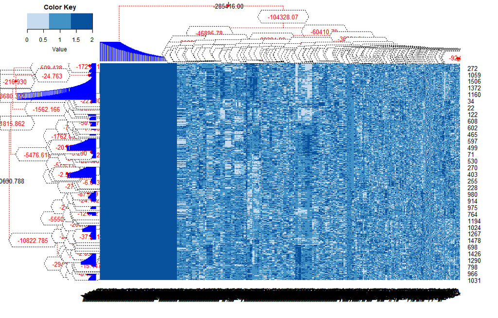

- 출처
  - 한지수,조형준. (2018). 연속형과 범주형 변수가 혼합된 데이터의 군집분석 연구. Journal of the Korean Data Analysis Society/20(4). 1769-1780. 한국자료분석학회.
  - Heller, K. A., & Ghahramani, Z. (2005). Bayesian hierarchical clustering. In Proceedings of the 22nd international conference on Machine learning (pp. 297-304). ACM.
  - Savage, R. S., Heller, K., Xu, Y., Ghahramani, Z., Truman, W. M., Grant, M., … & Wild, D. L. (2009). R/BHC: fast Bayesian hierarchical clustering for microarray data. BMC bioinformatics, 10(1), 242.
  - Abreu, N. (2011). Analise do perfil do cliente Recheio e desenvolvimento de um sistema promocional. Mestrado em Marketing, ISCTE-IUL, Lisbon
  - Dua, D. and Graff, C. (2019). UCI Machine Learning Repository [http://archive.ics.uci.edu/ml]. Irvine, CA: University of California, School of Information and Computer Science.